# Project 1: Basic plotting in Python 3 with matplotlib.pyplot

Before we start, please put your name and CUID in following format

: Firstname LASTNAME, #00000000 // e.g. Nianyi LI, #12345678

**Your Answer:**  
Carson Jack, #53602298

# General Rules of the Project Submission

Python 3 and [Matplotlib](https://matplotlib.org/) will be used throughout the semseter, so it is important to be familiar with them. It is strongly suggested to go through [Stanford CS231n](http://cs231n.github.io/python-numpy-tutorial/) and [CS228](https://github.com/kuleshov/cs228-material/blob/master/tutorials/python/cs228-python-tutorial.ipynb) for more detailed Python and numpy tutorials if you haven't had used Python before.

In some cells and files you will see code blocks that look like this:

```
##############################################################################
#                    TODO: Write the equation for a line                     #
##############################################################################
pass
##############################################################################
#                              END OF YOUR CODE                              #
##############################################################################
```

You should replace the `pass` statement with your own code and leave the blocks intact, like this:

```
##############################################################################
#                    TODO: Write the equation for a line                     #
##############################################################################
y = m * x + b
##############################################################################
#                              END OF YOUR CODE                              #
##############################################################################
```

When completing the notebook, please adhere to the following rules:

- Do not write or modify any code outside of code blocks
- Follow the instruction of the project description carefully
- Run all cells before submitting. **You will only get credit for code that has been run!**.

The last point is extremely important and bears repeating:

### We will not re-run your notebook -- you will only get credit for cells that have been run

### File name

Your Python program should be named **yourlastname_yourfirstname_P1.ipynb**, then zip it and upload to Canvas

# Python 3

If you're unfamiliar with Python 3, here are some of the most common changes from Python 2 to look out for.

### Print is a function

```python
print("Hello!")
```

```
Hello!
```

Without parentheses, printing will not work.

### Floating point division by default

```python
5 / 2
```

```
2.5
```

To do integer division, we use two backslashes:

```python
5 // 2
```

```
2
```

### No xrange

The xrange from Python 2 is now merged into "range" for Python 3 and there is no xrange in Python 3. In Python 3, range(3) does not create a list of 3 elements as it would in Python 2, rather just creates a more memory efficient iterator.

Hence, xrange in Python 3: Does not exist range in Python 3: Has very similar behavior to Python 2's xrange

```python
for i in range(3):
    print(i)
```

```
0
1
2
```

```python
range(3)
```

```
range(0, 3)
```

```python
# If need be, can use the following to get a similar behavior to Python 2's range:
print(list(range(3)))
```

```
[0, 1, 2]
```

# Project Description

## Data File

The first line of `IrisData.txt` contains two integers. The first represents how many lines of data are in the file. The second how many features are associated with each line. Each line after that contains four floating point values representing the sepal length, sepal width, petal length, and petal width of a type of iris flower, followed by the name of the iris type: either setosa, versicolor, or virginica. Values are tab separated.

## Python Program

Write a Python program that will print out a **two-dimensional plot** of any two features for all three varieties of iris flowers using the features of `matplotlib.pyplot`. Your program should begin by asking for the name of the input file. For example:

```
Enter the name of your data file: Irisdata.txt
```

```python
##############################################################################
#         TODO: Write the code for reading data from file                    #
##############################################################################
file = input("Enter the name of your data file: ") # Get the file name
f = open(file, 'r') # Open the file
print("The name of your file is: ", file) # Print the name of the file
##############################################################################
#                              END OF YOUR CODE                              #
##############################################################################
```

```
The name of your file is:  IrisData.txt
```

Then the program should prompt the user for two features to plot. For example, it could say:

```
You can do a plot of any two features of the Iris Data set The feature codes are:
0 = sepal length
1 = sepal width
2 = petal length
3 = petal width
```

```
Enter feature code For the horizontal axis: 0
Enter feature code For the vertical axis: 1
```

```python
##############################################################################
#   TODO: Write the function for plotting using two features of the data     #
##############################################################################
def get_feature_codes():
    x = int(input("Enter feature code For the horizontal axis: "))
    y = int(input("Enter feature code For the vertical axis: "))
    return x, y

def plot_feature_map():
    valid = [0,1,2,3]
    print("You can do a plot of any two features of the Iris Data set The feature codes are:\n0 = sepal length\n1 = sepal width\n2 = petal length\n3 = petal width\n")
    while True:
        x, y = get_feature_codes()
        if x in valid and y in valid:
            break
        else:
            print("Please enter valid feature codes")
    return x, y

x, y = plot_feature_map()
print("Your horizontal axis is:", x, "and your vertical axis is:", y)
##############################################################################
#                              END OF YOUR CODE                              #
##############################################################################
```

```
You can do a plot of any two features of the Iris Data set The feature codes are:
0 = sepal length
1 = sepal width
2 = petal length
3 = petal width

Please enter valid feature codes
Your horizontal axis is: 0 and your vertical axis is: 1
```

Once the program does a plot it should ask the user if they want to another plot. For example:

> Would you like to do another plot? (y/n) `y`

If the answer is `y`, then the user should be prompted for new features to plot on the horizontal and vertical axes as before and a new plot generated. `n` should end the program.

Plots should be labelled with a *title, axes should be labelled*, there should be a *legend* and all three varieties should be **color coded** and have different symbols. An example is shown below.

[figure not shown]

You need to try **at least 3 plots with different x and y labels combination**.

```
You can do a plot of any two features of the Iris Data set The feature codes are:
0 = sepal length
1 = sepal width
2 = petal length
3 = petal width
```

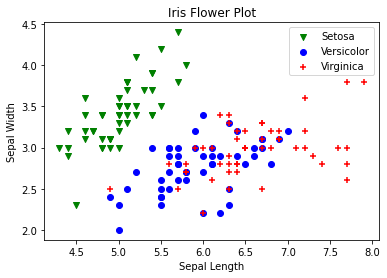

```
You can do a plot of any two features of the Iris Data set The feature codes are:
0 = sepal length
1 = sepal width
2 = petal length
3 = petal width
```

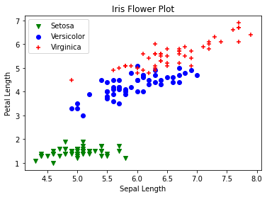

```
You can do a plot of any two features of the Iris Data set The feature codes are:
0 = sepal length
1 = sepal width
2 = petal length
3 = petal width
```

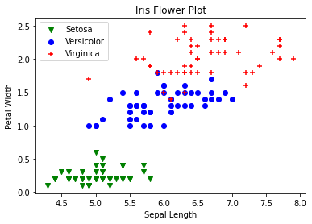

```
You can do a plot of any two features of the Iris Data set The feature codes are:
0 = sepal length
1 = sepal width
2 = petal length
3 = petal width
```

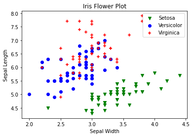

```
You can do a plot of any two features of the Iris Data set The feature codes are:
0 = sepal length
1 = sepal width
2 = petal length
3 = petal width
```

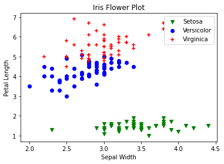

```
You can do a plot of any two features of the Iris Data set The feature codes are:
0 = sepal length
1 = sepal width
2 = petal length
3 = petal width
```

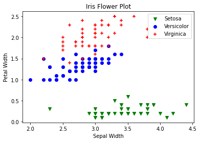

```
You can do a plot of any two features of the Iris Data set The feature codes are:
0 = sepal length
1 = sepal width
2 = petal length
3 = petal width
```

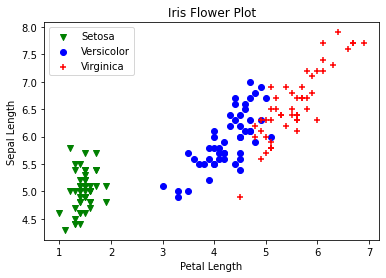

```
You can do a plot of any two features of the Iris Data set The feature codes are:
0 = sepal length
1 = sepal width
2 = petal length
3 = petal width
```

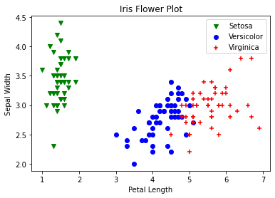

```
You can do a plot of any two features of the Iris Data set The feature codes are:
0 = sepal length
1 = sepal width
2 = petal length
3 = petal width
```

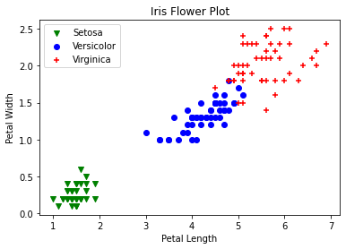

```
You can do a plot of any two features of the Iris Data set The feature codes are:
0 = sepal length
1 = sepal width
2 = petal length
3 = petal width
```

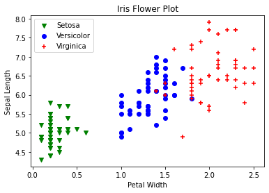

```
You can do a plot of any two features of the Iris Data set The feature codes are:
0 = sepal length
1 = sepal width
2 = petal length
3 = petal width
```

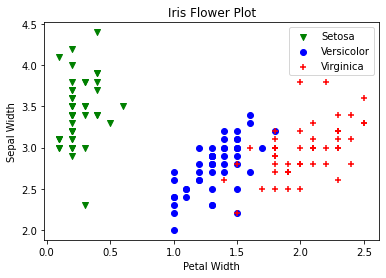

```
You can do a plot of any two features of the Iris Data set The feature codes are:
0 = sepal length
1 = sepal width
2 = petal length
3 = petal width
```

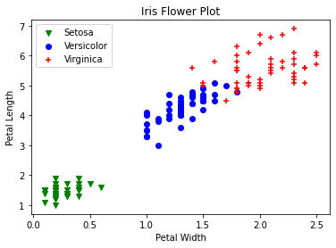

```python
##############################################################################
#          TODO: Use the loop function for plotting figures                 #
##############################################################################
import matplotlib.pyplot as plt

def get_feature_codes(): # Get input from user
    x = int(input("Enter feature code For the horizontal axis: "))
    y = int(input("Enter feature code For the vertical axis: "))
    return x, y

def plot_feature_map(): # Check if input is valid and return feature codes
    valid = [0,1,2,3]
    print("You can do a plot of any two features of the Iris Data set The feature codes are:\n0 = sepal length\n1 = sepal width\n2 = petal length\n3 = petal width\n")
    while True:
        x, y = get_feature_codes()
        if x in valid and y in valid:
            break
        else:
            print("Please enter valid feature codes")
    return x, y

def show_plot(): # Plot the feature code data
    plt.title("Iris Flower Plot")
    x, y = plot_feature_map()
    plt.xlabel(labels[x])
    plt.ylabel(labels[y])
    for i in range(len(setosa_data)):
        plt.scatter(setosa_data[i][x], setosa_data[i][y], color = "green", marker = 'v', label = "Setosa" if i==0 else "")
    for i in range(len(versicolor_data)):
        plt.scatter(versicolor_data[i][x], versicolor_data[i][y], color = "blue", label = "Versicolor" if i==0 else "")
    for i in range(len(virginica_data)):
        plt.scatter(virginica_data[i][x], virginica_data[i][y], color = "red", marker = '+', label = "Virginica" if i==0 else "")
    plt.legend()
    plt.show()

data = []
setosa_data = []
virginica_data = []
versicolor_data = []
labels = ["Sepal Length", "Sepal Width", "Petal Length", "Petal Width"]

with open("IrisData.txt", 'r') as f: # Read data from file
    for line in f:
        line_data = line.split('\t')
        data.append(line_data)

data.pop(0) # Remove the first line of the file
for i in range(len(data)): # Strip \n and separate Iris Types
    data[i][-1] = data[i][-1].strip()
    if data[i][-1] == "setosa":
        setosa_data.append(data[i])
    elif data[i][-1] == "virginica":
        virginica_data.append(data[i])
    elif data[i][-1] == "versicolor":
        versicolor_data.append(data[i])

for i in range(len(data)): # Convert to float
    for j in range(4):
        data[i][j] = float(data[i][j])

while True: # Plot loop
    show_plot()
    inp = input("\nWould you like to do another plot? (y/n) ")
    if inp == 'y':
        continue
    else:
        break
##############################################################################
#                              END OF YOUR CODE                              #
##############################################################################
```

# Conclusion

Briefly discuss **which feature combination is the best** for classify the iris data.

**Your Answer:**

```python
print("Based on the graphs generated from the dataset, it seems that the ratio of petal length to petal width is a good indicator of the type of flower.")
print("\nThis is because this combination of features seems to be the most distinct between the three types of flowers, meaning we can classify different clusters of data points are distinctly different types of flowers.")
```

```
Based on the graphs generated from the dataset, it seems that the ratio of petal length to petal width is a good indicator of the type of flower.

This is because this combination of features seems to be the most distinct between the three types of flowers, meaning we can classify different clusters of data points are distinctly different types of flowers.
```